# Analisis de Componentes Principales (Fundamentos e Inferencia)

## Paquetes

### *Loading*

Cargamos los paquetes que usaremos en estas ilustraciones.

```
# ripa
install.packages("ripa", dependencies=c("Depends", "Suggests"))
# EBImage
source("http://bioconductor.org/biocLite.R")
biocLite("EBImage")
# kernel
```

```
if (require("fields") == FALSE){
  install.packages("fields")
}
if (require("mnormt") == FALSE){
  install.packages("mnormt")
}
if (require("MCMCpack") == FALSE){
  install.packages("MCMCpack")
}
if (require("actuar") == FALSE){
  install.packages("actuar")
}
if (require("ggplot2") == FALSE){
  install.packages("ggplot2")
}
library("fields","mnormt","MCMCpack","actuar")
library("ggplot2")
library("kernlab")
library("stats")
```

## Parte 1 - Fundamentos

## PCA-Fundamentos

### Intuicion

El *analisis de componentes principales* (o PCA por sus siglas en ingles) es una de las tecnicas de *reduccion de dimensionalidad* mas empleada en la practica.

Se emplea en diferentes contextos, por ejemplo:

1. Ortogonalizar datos (matrices) (***)
2. Definir modelos de regresion donde \(Y=M\beta + \varepsilon\), donde \(M\) es un conjunto de componentes de componentes principales de los datos originales \(X\)
3. Procesamiento y reconstruccion de se;ales e imagenes
4. Construccion de indices (sobre todo en las ciencias sociales)
5. Otras muchas aplicaciones…

## PCA-Fundamentos

### Intuicion

- El Analisis de Componentes Principales (PCA) es una tecnica que comunmente se emplea para realizar **analisis exploratorio de datos** y **reduccion de dimensionalidad**
- Usualmente, PCA se asocia con el siguiente procedimiento

> Tomar un conjunto de observaciones multidimensionales y correlacionadas entre si, reemplazandolas por un numero de NUEVAS observaciones de dimension menor y no correlacionadas
- La interpretacion anterior no es enteramente correcta, pues PCA es mas bien un procedimiento para la **ortogonalizacion de datos correlacionados** en la que

> las nuevas variables son generadas mediante un procedimiento de rotacion de los datos originales, con cada componente dirigido hacia la dimension de los datos originales con la mayor variabilidad

## PCA-Fundamentos

### Analisis exploratorio de datos

Supongamos que tenemos un conjunto de datos asociado con \(p\) variables \[X_1,\ldots,X_p\]

- La interrelacion entre estas \(p\) variables podria visualizarse usando \(\frac{p(p-1)}{2}\) diagramas de dispersion (esto solo para visualizar relaciones 1:1 entre las \(p\) variables)
- **Con PCA puede obtenerse:**
1. simplificacion de la informacion contenida en las variables originales, pero en una menor dimension,
2. resumen de las dimensiones/variables originales que campuran la mayor cantidad de informacion, asi como la cuantificacion relativa a tal informacion para cada variable

## PCA-Fundamentos

### Formulacion

PCA mapea la informacion de \[(X_1,\ldots,X_p)\rightarrow(Z_1,\ldots,Z_p)\]

–\(X_j\)s correlacionadas, mientras que \(Z_j\)s no correlacionadas–

**Componentes** \[Z_j=<\phi,X>=\phi'X=\sum_{i=1}^{p} \phi_{ji} X_i,\]

- **pesos normalizados**, i.e. \(<\phi,\phi> = 1\)
- \((\phi_{j1},\ldots,\phi_{jp})\) es el **vector de cargas** del \(j\)-esimo componente principal (eigenvector)

## PCA-Fundamentos

### Calculo

Considerando un conjunto de datos en forma matricial \(X=(X_{ij})_{i=1,j=1}^{n,p}\) de dimension \(n\times p\) (considerando \(n >> p\))

La contruccion del PCA se obtiene como un **problema de optimizacion**, en le que inicialmente, el **primer componente principal** se define como la solucion a \[ \max_{\phi_{11},\ldots,\phi_{1p}}\left\{\frac{1}{n}\sum_{i=1}^{n}\left(\sum_{j=1}^{p}\phi_{1j}x_{ij}\right)^{2}\right\} \text{ s.a. } \sum_{j=1}^{p}\phi_{1j}^2=1. \] **Nota:** Se supone que las \(X_{ij}\)s son estandarizadas. De forma que \(\frac{1}{n}\sum_{i=1}^{n}X_{ij}=0\), por lo que la funcion objetivo a maximizar puede definirse como \(\frac{1}{n}Z_{i1}^2.\)

- El ultimo componente se refiere a la varianza muestral de los *scores* \(Z_{i1}\)s correspondiente a la primera dimension de los nuevos componentes principales.

## PCA-Fundamentos

### **Supuestos**

- **Linealidad:** La nueva base es una combinación lineal de la base original
- **Suficiencia:** La media y la varianza son estadísticas suficientes. PCA supone que estas estadísticas describen totalmente la distribución de los datos a lo largo del eje (es decir, la distribución normal).
- **Variablidad:** Las grandes variaciones tienen una dinámica importante: alta varianza significa señal, baja varianza significa ruido. Esto significa que el PCA implica que la dinámica tiene una alta relación señal / ruido.
- **Ortonormalidad:** Los componentes que se contruyen seran ortonormales, a.k.a. estocastimanete independientes.

Suponemos que la matriz de covarianza muestral de \(X\) está dada por \(\frac{1}{n-1}(X'X)\).

## PCA-Fundamentos

### Algebra Matricial

**La solucion del problema de optizacion puede verse como la solucion a un problema de algebra matricial.**

Si \(X\) es el conjunto de datos original, \(Z\) es el conjunto de datos transformado (ambos con el tamaño \(n \times p\)) y \(P\) es la transformación lineal (\(p \times p\)), dada por \[ XP = Z, \] \(P\) puede verse como la matriz que transforma \(X\) en \(Z\), o como la **transformacion geométrica (rotacion + estiramiento)** que transforma a \(X\) en \(Z\).

- Las filas de \(P\) son el conjunto de vectores que definen la nueva base para expresar las columnas de $ X $. Estos vectores de fila, si están debidamente definidos, son los componentes *principales* de \(X\).
- La matrix \(P\) corresponde a la matriz con eigenvectores de la descomposicion espectral de la matriz \(\frac{1}{n-1}X'X\).

## PCA-Fundamentos

### Calculo

Consideremos el siguiente conjunto de datos

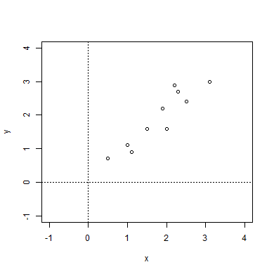

Datos originales

## PCA-Fundamentos

### Calculo

Estandarizando los datos por la media (muestral).

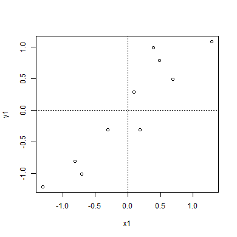

Datos estandarizados por la media

## PCA-Fundamentos

### Calculo

Calculamos la matriz de varianzas y covarianzas muestral, junto con su determinante.

```
##        [,1]  [,2]
##  [1,]  0.69  0.49
##  [2,] -1.31 -1.21
##  [3,]  0.39  0.99
##  [4,]  0.09  0.29
##  [5,]  1.29  1.09
##  [6,]  0.49  0.79
##  [7,]  0.19 -0.31
##  [8,] -0.81 -0.81
##  [9,] -0.31 -0.31
## [10,] -0.71 -1.01
```

```
##           [,1]      [,2]
## [1,] 0.6165556 0.6154444
## [2,] 0.6154444 0.7165556
```

```
## [1] 0.06302444
```

## PCA-Fundamentos

### Calculo

Calculamos los **eigenvectores** y **eigenvalores** de la matriz de covarianzas:

```r
cov.eig <- eigen(cov.m)
cov.eig
```

```
## eigen() decomposition
## $values
## [1] 1.2840277 0.0490834
##
## $vectors
##           [,1]       [,2]
## [1,] 0.6778734 -0.7351787
## [2,] 0.7351787  0.6778734
```

```r
# verificando ortogonalidad
cov.eig$vectors[,1] %*% cov.eig$vectors[,2]
```

```
##               [,1]
## [1,] -1.106389e-17
```

```r
# visualizacion
```

## PCA-Fundamentos

### Calculo

Visualizamos la descomposicion espectral. La linea `roja` representa el primer componente principal, la `verde` representa el segundo componente principal.

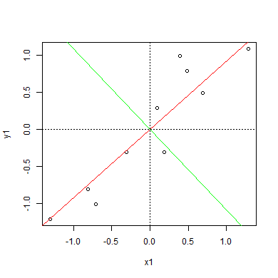

Creacion de nuevos ejes

## PCA-Fundamentos

### Calculo

Una vez encontrados los **eigenvectores**, debemos ordenarlos coin base en sus **eigenvalores**. Esto nos da los componentes por orden de importancia! Podemos decidir ignorar los componentes con menor `significado`/`variabilidad capturada`, sin embargo, perderemos informacion pero no tanto si sus valores son pequenos.

## PCA-Fundamentos

### Calculo

En nuestro ejemplo en 2D, solo tenemos dos opciones para ordenar los **eigenvalores**. Iluestremos este procedimiento:

```r
# un componente
f.vector1 <- as.matrix(cov.eig$vectors[,1],ncol=1)
f.vector1
```

```
##           [,1]
## [1,] 0.6778734
## [2,] 0.7351787
```

```r
# dos componentes
f.vector2 <- as.matrix(cov.eig$vectors[,c(1,2)],ncol=2)
f.vector2
```

```
##           [,1]       [,2]
## [1,] 0.6778734 -0.7351787
## [2,] 0.7351787  0.6778734
```

## PCA-Fundamentos

Derivamos el nuevo conjunto de datos transformados. Si \(X\) es el conjunto de `datos` originales y \(P\) es el vector de atributos, entonces la transpuesta de los datos transformados es \(X P'\) define a las nuevas variables:

```r
# un vector
final1 <- t(f.vector1) %*% t(m)
# dos vectores
final2 <- t(f.vector2) %*% t(m)
final2
```

```
##            [,1]       [,2]      [,3]      [,4]       [,5]      [,6]
## [1,]  0.8279702 -1.7775803 0.9921975 0.2742104  1.6758014 0.9129491
## [2,] -0.1751153  0.1428572 0.3843750 0.1304172 -0.2094985 0.1752824
##             [,7]        [,8]        [,9]      [,10]
## [1,] -0.09910944 -1.14457216 -0.43804614 -1.2238206
## [2,] -0.34982470  0.04641726  0.01776463 -0.1626753
```

```r
# nueva matriz de covarianza
cov(t(final2))
```

```
##              [,1]        [,2]
## [1,] 1.284028e+00 4.70363e-17
## [2,] 4.703630e-17 4.90834e-02
```

## PCA-Fundamentos

### `Nuevos vectores`

Estos conjuntos de datos finales son los datos originales en términos de los vectores que elegimos, es decir, ya no estan sobre los ejes `x` y `y` originales, sino que utilizan los vectores propios elegidos como su nuevo eje.

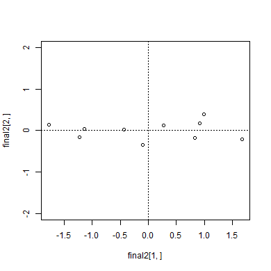

## PCA-Fundamentos

### Recuperando `vectores originales`

Recuperando los datos originales…

```r
# con todos los eigenvectores - recuperacion al 100% (como en final2)
original.dataset2 <- t(f.vector2 %*% final2)
original.dataset2[,1] <- original.dataset2[,1] + mean(x)
original.dataset2[,2] <- original.dataset2[,2] + mean(y)
original.dataset2
```

```
##       [,1] [,2]
##  [1,]  2.5  2.4
##  [2,]  0.5  0.7
##  [3,]  2.2  2.9
##  [4,]  1.9  2.2
##  [5,]  3.1  3.0
##  [6,]  2.3  2.7
##  [7,]  2.0  1.6
##  [8,]  1.0  1.1
##  [9,]  1.5  1.6
## [10,]  1.1  0.9
```

## PCA-Fundamentos

### Recuperando `vectores originales`

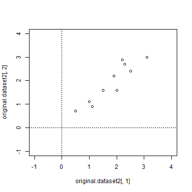

Volciendo a los datos orginales

## PCA-Fundamentos

### Que sigue?

- Construir PCA incorporando **incertidumbre epistemica** (a.k.a. error de estimacion de la matriz de covarianzas)
- Extender PCA para **objetos no matriciales** (e.g. `imagenes` o `textos`)
- Vincular PCA con `analisis de factores` y `analisis de correlacion canonica`
- Definir PCA para datos `ralos` (i.e. `sparce data`)